# Data Mining Versuch Music Clustering

- Autor: Prof. Dr. Johannes Maucher
- Datum: 16.10.2015

Übersicht Ipython Notebooks im Data Mining Praktikum

# Einführung

## Lernziele:

In diesem Versuch sollen Kenntnisse in folgenden Themen vermittelt werden:

- Zugriff auf Musikdateien
- Transcodierung von mp3 zu wav
- Extraktion von Merkmalen in Musikdateien (Feature Extraction)
- Optimierung mit dem genetischen Algorithmus
- Selektion der aussagekräftigsten Merkmale (Feature Selection)
- Clustering von Musikfiles (automatische Playlistgenerierung)

## Vor dem Versuch zu klärende Fragen

### Transcodierung von MP3 nach WAV und Merkmalsextraktion

In diesem Versuch wird der MP3 Decoder [mpg123](http://www.mpg123.de/) eingesetzt. Installieren und testen sie diesen Decoder vor dem Versuch auf ihrem Rechner. Machen Sie sich zunächst mit dem in Kapitel Gegebene Module zur Transcodierung und Feature Extraction aufgeführten Code vertraut. Versuchen Sie Funktion und Ablauf dieses Programms zu verstehen und beantworten Sie folgende Fragen.

1. Was versteht man unter den statistischen Größen *Mittelwert, Standardabweichung, Skewness und Kurtosis*?

#### Mittelwert

Mit dem Begriff Mittelwert (*auch Durchschnitt genannt*) ist in der Statistik meistens das *artithmetische Mittel* gemeint. Der Mittelwert ist dabei eine Kennzahl für die zentrale Tendenz einer Verteilung. Das arithmetische Mittel ist rechnerisch die Summe der gegebenen Werte geteilt durch die Anzahl der Werte. Angewandt kann dies beispielsweise zum Berechnen einer Durchschnittsgeschwindigkeit werden. In diesem Fall würden die Werte als Geschwindigkeit interpretiert werden. Der *Erwartungswert* einer Zufallsvariablen beschreibt hingegen die Zahl, die die Zufallsvariable im Mittel annimmt.

#### Standardabweichung

Die Standardabweichung ist ein Maß dafür, wie weit einzelne Datensätze verteilt sind. Mathematisch wird die Standardabweichung definiert als die mittlere quadratische Abweichung einer reellen Zufallsvariablen von ihrem Erwartungswert. Wenn alle Werte gleich sind, so ist die Standardabweichung Null, da diese von der Varianz abgeleitet ist. Das heißt je weiter Daten vertreut sind, desto höher ist die Standardabweichung. Je enger/näher Datensätze jedoch beieinander liegen, desto niedriger fällt die Standardabweichung aus. Es gibt zwei verschiedene Formeln der Anwendung, welche sich darin unterscheiden, dass nicht durch *n*, sondern durch *n-1* geteilt wird.

- die Standardabweichung für eine Stichprobe, wenn die Ergebnisse generalisierbar sein sollen. D.h. man möchte Ergebnisse erzielen, die es ermöglichen auf alle Menschen und nicht nur auf die ursprügnliche Versuchsgruppe *x* Rückschlüsse zu ziehen.
- die Standardabweichung für die Grundgesamtheit, wenn die Ergebnisse nicht verallgemeinert werden sollen. D.h. die Ergebnisse gelten nur für die Versuchsgruppe *x*.

#### Skewness

Die Maßzahl der Schiefe (*eng. skewness*) gibt an, inwieweit eine Verteilungsfunktion sich zu einer Seite "neigt". Das heißt diese ist ein Maß für die Asymmetrie einer Verteilung. Der Wert kann dabei *positiv* (Verteilungsfunktion tendiert nach rechts), *negativ* (Verteilungsfunktion tendiert nach links), *null* (Verteilungsfunktion ist symmetrisch) und *undefiniert* (0/0) sein.

###### Eigenschaften einer unimodalen Verteilung

- linksschief (identisch mit dem Begriff rechtssteil) Verteilungen ist der Median größer als das arithmetische Mittel.
- rechtsschief (identisch mit dem Begriff linkssteil) Verteilungen ist der Modus kleiner als der Erwartungswert
- Ist die Verteilungsfunktion symmetrisch, so ist das arithmetische Mittel gleich dem Median und die Verteilung wird eine Schiefe von 0 haben.

#### Kurtosis

Die Kurtosis (*dt. Wölbung*) ist ein Maß für die Steilheit einer Wahrscheinlichkeitsfunktion, oder Häufigkeitsverteilung. Verteilungen mit geringer Wölbung streuen relativ gleichmäßig.Verteilungen mit niederger Kurtosis streuen relativ gleichmäßig(breite Glocke), Verteilungen mit hoher Kurtosis haben eine mehr extreme auf einem Punkt verteilte Streuung(spitze Glocke).

1. Was beschreibt die Fourier-Transformierte eines zeitlich ausgedehnten Signals?

#### Die Fourier Transformation

Die Fourier-Transformation (genauer die kontinuierliche Fourier-Transformation ist eine mathematische Methode aus dem Bereich der Fourier-Analysis, mit der kontinuierliche, aperiodische Signale in ein kontinuierliches Spektrum zerlegt werden. Die Funktion, die dieses Spektrum beschreibt, nennt man auch Fourier-Transformierte oder Spektralfunktion. Es handelt sich dabei um eine Integraltransformation, die nach dem Mathematiker Jean Baptiste Joseph Fourier benannt ist. Fourier führte im Jahr 1822 die Fourier-Reihe ein, die jedoch nur für periodische Signale definiert ist und zu einem diskreten Frequenzspektrum führt. Die Entwicklung einer Funktion in ihre *Fourier-Reihe* wird harmonische Analyse genannt. Die Funktion wird dabei als Überlagerung von sinusförmigen, Schwingungen dargestellt. Ist die Funktion ein Eingangssignal eines LTI-Systems, kann das Ausgangssignal relativ einfach berechnet werden, da das Signals als Überlagerung von Eigenfunktionen des Systems vorliegt.

Kurz: Die *Fourier Transformation* zerlegt das Signal in verschiedene Sinuswellen, aus denen es besteht. Sie gibt an mit welcher Intensität die einzelnen Frequenzen im zeitlich ausgedehnten Signal vorkommen.

1. Mit welcher Samplingrate werden die WAV Dateien abgetastet?

#### Abtastrate von WAV Dateien

Die Abtastrate oder Abtastfrequenz, auch Samplingrate, Samplerate oder Samplingfrequenz, ist in der Signalverarbeitung die Häufigkeit, mit der ein Analogsignal (auch zeitkontinuierliches Signal genannt) in einer vorgegebenen Zeit abgetastet (das heißt, gemessen und in ein zeitdiskretes Signal umgewandelt) wird. Da es sich bei einer Abtastung immer um einen periodischen Vorgang handelt, ist ihre grundlegende Einheit das *Hertz* (abgekürzt: Hz), also Perioden pro Sekunde.

- Ein Abtastvorgang pro Sekunde: 1 Hz = 1 S/s
- Bei CDs werden die Audiodateien als WAV-Dateien mit 44.1Khz Abtastrate abgespeichert.
- Die Sample Rate dieses Versuches wird in -r 10.000 angegeben.

Die Waveform Audi File Format (*WAV*) ist eine von IBM und Microsoft entwickeltes Containerformat für die Speicherung von Audiodaten. Die in den Containern enthaltenen Dateien sind normalerweise unkomprimierte in *Pulscodemodulation (PCM)* codierte Audiosignale für die Speicherung und Bearbeitung von Audio-Informationen. WAV-Dateien sind unkomprimiert und fehlerfrei, aber relativ groß. Ihre Größe ergibt sich aus der Abtastrate und der Samplingtiefe bei der Digitalisierung des analogen Audiosignals. Daraus ergibt sich bei einer standardmäßigen Abtastrate von **44,1 kHz** und einer Samplingtiefe von **16 Bit** eine Dateigröße von **5,3 Megabyte (MB) pro Minute** für ein Monosignal. Es sind allerdings auch andere Abtastraten und Sampletiefen möglich.

1. Insgesamt werden 42 Merkmale pro Musiksequenz extrahiert. Beschreiben Sie kurz diese Merkmale

#### Merkmalsextraktion bei WAV Dateien

Die extrahierten Merkmale betreffen die Kurtuosis. Diese Merkmale liegen sowohl im Spektralbereich, als auch im Zeitbereich.

*amp1/amp10/amp100/amp1000: Verschieden starke Glättung von 1, 10, 100 und 1000 samples*

- mean: Mittelwert
- dstd: Wir haben dazu nichts gefunden
- std: Standartabweichung
- skew: Skewness
- kurt: Kurtosis
- power1-power10: Spalten den Frequenzbereich in 10 Bereiche und geben den Pegel in dem jeweiligen Bereich an.

### Matching der Teilsequenzen

1. Nachdem für jedes Musikstück die beiden Teilsequenzen in Form der extrahierten Merkmale vorliegen: Wie kann die Ähnlichkeit zwischen Teilsequenzen ermittelt werden?

Die Musikstücke, welche als Trainingsdaten vorliegen, werden die einzelnen Teilsequencen in Vektoren umgewandelt und anschließend auf deren Ähnlichkeit miteinander vergliechen. Haben diese eine hohe Ähnlichkeit, so so müsste das erste Teilstück und das zweite Teilstück gleich oder sehr ähnlich sein.

1. Welche Numpy- bzw. Scipy-Module können Sie für die Bestimmung der Ähnlichkeit zwischen Teilsequenzen einsetzen?

Aus der Scipy Libary können folgende Funktionen angewandt werden, um die Ähnlichkeit der einzelnen Teilsequenzen zu berechnen.

```
scipy.spatial.distance.euclidean (Euklid)

scipy.stats.pearsonr (Pearson)

scipy.spatial.distance.cosine (Kosinus)
```

## Genetischer Algorithmus für die Merkmalsselektion

1. Beschreiben Sie die Prozesschritte im genetischen Algorithmus [Genetischer Algorithmus](https://www.hdm-stuttgart.de/~maucher/Python/FunktionenAlgorithmen/html/genAlgTSP.html)

#### Der Genetische Algorithmus

Ein Genetischer Algorithmus (GA) ist eine Such-Heuristik, welche durch *Charls Darwin's* Theorie der natürlichen Evolution inspiriert wurde. Dieser reflektiert den Prozess, in welchem eine natürliche Selektion der besten (*fittest*) Individuen einer Population für eine Reproduktion selektiert werden. Genetische Algorithmen (GA) sind sehr gut für Probleme in der Suche, als auch für Optimierungen einzusetzen. Ein Beispiel hierfür ist der Einsatz eines *GA*, um eine Lösung für das "Travelling Salesman Problem" (TSP) zu finden. Für die Erkundung der besten Merkmale in diesem Fall werden die einzelnen Elemente des GA auf die Problemstellung wie folgt übertragen:

- **Gene**: Satz an Parametern (Variablen).
- **Individual/Chromosome**: Ein Chromosom ist eine Zusammensetzung von Genen. In diesem Fall ein einzelnes Merkmal, welches die Bedingungen erfüllt.
- **Population**: Eine Sammlung möglicher Merkmale.
- **Parents**: Zwei Merkmale, welche kombiniert werden, um ein neues Merkmal zu generieren.
- **Mating Pool**: Eine Sammlung an Elternteilen, welche dazu verwendet werden, eine neue Population (nächste Generation) zu generieren.
- **Fitness**: Eine Funktion, welche die Güte der Mermale anhand ihres *mittleren Rangs* bewertet.
- **Mutation**: Eine Möglichkeit Variationen in der Population zu erzeugen, durch zufälliges austauschen von Elementen der Merkmale.

#### Die Schritte der Ausführung des Genetischen Algorithmus

##### Erzeugung zufälliger Population:

Erzeugt eine Menge von Individuen mit zufälligen Chromosomen. Jedes Individum ist ein Lösungsvorschlag für ein Problem.

##### Bestimme Fitness:

Individuen werden anhand einer Fitnessfunktion bewertet.

##### Selektion:

Wähle ein Paar von Individuen aus. Die Auswahl ist von der Fitness abhängig. Je höher die Fitness, desto höher die Wahrscheinlichkeit, dass sie für die Kreuzung ausgewählt werden.

##### Kreuzung:

Paare werden gekreuzt und erzeugen Nachkommen, welche die Chromosomen der Eltern erben. Hier wird ein zufälliger Schnittpunkt zur Vereinigung der Elternvektoren genutzt. Die Chromosome werden an dieser Stelle geteilt und miteinander vertauscht.

##### Mutation:

Ein Teil der Chromosomen wird zufällig verändert. Es gibt eine Mutationswahrscheinlichkeit, folglich kommt es nicht immer zu einer Mutation.

##### Austausch:

Wenn einer der Nachkommen eine bessere Fitness besitzt als einer aus der Ursprungspopulation, wird dieser ersetzt. Dabei dürfen keine Duplikate entstehen.

##### Abbruchbedingung:

Gibt an wann die Schleife beendet wird. In der Regel wird der genetische Algorithmus beendet wenn nach vielen Iteration die Fitness sich nicht verbessert, manchmal auch nach einer festgelegten Anzahl an Iterationen.

1. In diesem Versuch wird davon ausgegangen, dass Merkmale dann gut sind, wenn durch sie die erste Teilsequenz eines Musikstücks durch einen ähnlichen Vektor wie die jeweils zweite Teilsequenz beschrieben wird. Wie kann mit dieser Annahme der genetische Algorithmus für die Merkmalsselektion angewandt werden. Unter Merkmalsselektion versteht man allgemein die Suche nach den $r$ besten Merkmalen aus einer Menge von insgesamt $R$ Merkmalen. In diesem Versuch werden initial $R=42$ Merkmale extrahiert, aus denen dann die besten $r<R$ Merkmale zu bestimmen sind. Überlegen Sie hierfür speziell wie die Fitnessfunktion, die Kreuzung und die Mutation zu realisieren sind.

##### Fitnessfunktion:

Euklidische Distanz der verwendeten Features zwischen der ersten und der zweiten Teilsequenz. Diese errechneten Werte werden aufsteigend sortiert in einem Array abgespeichert. Danach wird aus dem Array ein Mittlerer Rang(siehe Aufgabebeschreibung Matching der Teilsequenzen 4.) berechnet. Dieser spiegelt die Fitness wieder.

##### Kreuzung:

Indivduen mit niedriger Distanz bzw. mit gutem Fitnesswert werden miteinander gekreuzt. Dabei wird ein zufälliger Schnittpunkt zur Vereinigung der Elternvektoren genutzt. Die Chromosome werden an dieser Stelle geteilt und miteinander vertauscht.

##### Mutation:

Mit niedriger Wahrscheinlichkeit wird ein Wert zufällig verändert.

### Clustering und Playlistgenerierung

1. Wie kann mit einem hierarchischen Clustering der Musikfiles eine Menge von Playlists erzeugt werden, so dass innerhalb einer Playlist möglichst ähnliche Titel zu finden sind?

Titel, die im Clustering nahe beieinander liegen, werden in eine Playlist genommen. Je größer man die Cluster macht, desto unähnlicher werden die Titel untereinander sein.

In dem Prozess werden ähnliche Songs zu einem Cluster zusammengefügt. Danach werden Cluster, die sich ähnlich sind, zu Clustern zusammengefügt usw.

# Durchführung

## Gegebene Module zur Transcodierung und Feature Extraction

Mit dem in diesem Abschnitt gegebenen Code werden die im Unterverzeichnis *BandCollection* befindlichen mp3-Files zunächst in wave decodiert. Danach werden aus den wave Dateien Audiomerkmale erhoben.

Von jedem Musikstück werden zwei disjunkte Teilsequenzen erhoben und von beiden Teilsequenzen jeweils ein Merkmalsvektor gebildet. Der Grund hierfür ist: Für die später folgende Bestimmung der wichtigsten Merkmale (Merkmalsselektion mit dem genetischen Algorithmus), wird angenommen dass Merkmale dann gut sind, wenn die aus ihnen gebildeten Merkmalsvektoren für Teilsequenzen des gleichen Musikstücks nahe beieinander liegen und die Merkmalsvektoren von Teilsequenzen unterschiedlicher Musikstücke weiter voneinander entfernt sind. In der Merkmalsselektion werden dann die Merkmale als relevant erachtet, für die diese Annahme zutrifft.

**Aufgaben:**

1. Stellen Sie im unten gegebenen Code die Verzeichnisse für Ihre Musikdateien (aktuell Unterverzeichnis *BandCollection*) und für den Ort Ihres *mpg123* Decoders richtig ein.
2. Die verwendete Musiksammlung sollte mindestens 5 verschiedene Interpreten möglichst unterschiedlicher Genres enthalten. Von jedem Interpret sollten mehrere Titel (evtl. ein ganzes Album) enthalten sein.
3. Führen Sie den in diesem Abschnitt gegebenen Programmcode zur Audiofeature-Extraction aus. Damit werden für alle Musiksequenzen jeweils 42 Merkmale extrahiert. Die extrahierten Merkmalsvektoren der jeweils ersten Sequenz werden in das File *FeatureFileTrainingAllList1.csv* geschrieben, die der zweiten Teilsequen in das File *FeatureFileTestAllList2.csv*.

```python
import subprocess
import wave
import struct
import numpy
import os
import pandas as pd

numpy.set_printoptions(precision=2,suppress=True)

#Names of features extracted in this module
FeatNames=["amp1mean","amp1std","amp1skew","amp1kurt","amp1dmean","amp1dstd","amp1dskew","amp1dkurt","amp10mean","amp10std",
           "amp10skew","amp10kurt","amp10dmean","amp10dstd","amp10dskew","amp10dkurt","amp100mean","amp100std","amp100skew",
           "amp100kurt","amp100dmean","amp100dstd","amp100dskew","amp100dkurt","amp1000mean","amp1000std","amp1000skew",
           "amp1000kurt","amp1000dmean","amp1000dstd","amp1000dskew","amp1000dkurt","power1","power2","power3","power4",
           "power5","power6","power7","power8","power9","power10"]
```

```python
def moments(x):
    mean = x.mean()
    std = x.var()**0.5
    skewness = ((x - mean)**3).mean() / std**3
    kurtosis = ((x - mean)**4).mean() / std**4
    return [mean, std, skewness, kurtosis]
```

```python
#Feature category 2: Frequency domain parameters
def fftfeatures(wavdata):
    f = numpy.fft.fft(wavdata)
    f = f[2:int(f.size / 2 + 1)]
    f = abs(f)
    total_power = f.sum()
    f = numpy.array_split(f, 10)
    return [e.sum() / total_power for e in f]
```

```python
#Creating the entire feature vector per music-file
def features(x):
    x = numpy.array(x)
    f = []

    xs = x
    diff = xs[1:] - xs[:-1]
    f.extend(moments(xs))
    f.extend(moments(diff))

    xs = x.reshape(-1, 10).mean(1)
    diff = xs[1:] - xs[:-1]
    f.extend(moments(xs))
    f.extend(moments(diff))

    xs = x.reshape(-1, 100).mean(1)
    diff = xs[1:] - xs[:-1]
    f.extend(moments(xs))
    f.extend(moments(diff))

    xs = x.reshape(-1, 1000).mean(1)
    diff = xs[1:] - xs[:-1]
    f.extend(moments(xs))
    f.extend(moments(diff))

    f.extend(fftfeatures(x))
    return f
```

```python
def read_wav(wav_file):
    """Returns two chunks of sound data from wave file."""
    w = wave.open(wav_file)
    n = 60 * 10000
    if w.getnframes() < n * 3:
        raise ValueError('Wave file too short')
    #For each music file 2 sequences, each containing n frames are subtracted. The first sequence starts at postion n,
    #the second sequence starts at postion 2n. The reason for extracting 2 subsequences is, that later on we like to
    #find the best features and in this exercise we assume that good features have the property that they are similar for 2 subsequences
    #of the same song, but differ for subsequences of different songs.
    w.setpos(n)
    frames = w.readframes(n)
    wav_data1 = struct.unpack('%dh' % n, frames)
    frames = w.readframes(n)
    wav_data2 = struct.unpack('%dh' % n, frames)
    return wav_data1, wav_data2
```

```python
def compute_chunk_features(mp3_file):
    """Return feature vectors for two chunks of an MP3 file."""
    # Extract MP3 file to a mono, 10kHz WAV file
    #mpg123_command = 'C:\Program Files (x86)\mpg123-1.22.0-x86\mpg123-1.22.0-x86\\mpg123.exe -w "%s" -r 10000 -m "%s"'
    #mpg123_command = 'C:\\Program Files (x86)\\mpg123-1.21.0-x86-64\\mpg123.exe -w "%s" -r 10000 -m "%s"'
    mpg123_command = 'C:/Users/HofAl/Documents/DataMiningLab-master/mpg123-1.24.0-x86-64/mpg123-1.24.0-x86-64\\mpg123.exe -w "%s" -r 10000 -m "%s"'
    #mpg123_command = '/content/drive/My Drive/Colab Notebooks/BandCollection
    out_file = 'temp.wav'
    cmd = mpg123_command % (out_file, mp3_file)
    temp = subprocess.call(cmd)
    # Read in chunks of data from WAV file
    wav_data1, wav_data2 = read_wav(out_file)
    # We'll cover how the features are computed in the next section!
    return numpy.array(features(wav_data1)), numpy.array(features(wav_data2))
```

```python
fileList=[]
featureList1=[]
featureList2=[]
#Specify the name of the directory, which contains your MP3 files here.
# This directory should contain for each band/author one subdirectory, which contains all songs of this author
for path, dirs, files in os.walk('./BandCollection'):
    #print '-'*10,dirs,files
    for f in files:
        if not f.endswith('.mp3'):
            # Skip any non-MP3 files
            continue
        mp3_file = os.path.join(path, f)
        print (mp3_file)
        # Extract the track name (i.e. the file name) plus the names
        # of the two preceding directories. This will be useful
        # later for plotting.
        tail, track = os.path.split(mp3_file)
        tail, dir1 = os.path.split(tail)
        tail, dir2 = os.path.split(tail)
        # Compute features. feature_vec1 and feature_vec2 are lists of floating
        # point numbers representing the statistical features we have extracted
        # from the raw sound data.
        try:
            feature_vec1, feature_vec2 = compute_chunk_features(mp3_file)
        except:
            print ("Error: Chunk Features failed")
            continue
        #title=str(track)
        title=str(dir1)+'\\'+str(track)
        print ('-'*20+ title +'-'*20)
        #print "       feature vector 1:",feature_vec1
        #print "       feature vector 2:",feature_vec2
        fileList.append(title)
        featureList1.append(feature_vec1)
        featureList2.append(feature_vec2)

# Write feature vecotrs of all music files to pandas data-frame
MusicFeaturesTrain=pd.DataFrame(index=fileList,data=numpy.array(featureList1),columns=FeatNames)
MusicFeaturesTrain.to_csv("FeatureFileTrainingAllList1.csv")

MusicFeaturesTest=pd.DataFrame(index=fileList,data=numpy.array(featureList2),columns=FeatNames)
MusicFeaturesTest.to_csv("FeatureFileTestAllList2.csv")
```

```
./BandCollection\Adele\01 Hometown Glory.mp3
--------------------Adele\01 Hometown Glory.mp3--------------------
./BandCollection\Adele\02 I'll Be Waiting.mp3
--------------------Adele\02 I'll Be Waiting.mp3--------------------
./BandCollection\Adele\03 Don't You Remember.mp3
--------------------Adele\03 Don't You Remember.mp3--------------------
./BandCollection\Adele\04 Turning Tables.mp3
--------------------Adele\04 Turning Tables.mp3--------------------
./BandCollection\Adele\05 Set Fire To The Rain.mp3
--------------------Adele\05 Set Fire To The Rain.mp3--------------------
./BandCollection\Adele\06 If It Hadn't Been For Love.mp3
--------------------Adele\06 If It Hadn't Been For Love.mp3--------------------
./BandCollection\Adele\07 My Same.mp3
Error: Chunk Features failed
./BandCollection\Adele\08 Take It All.mp3
--------------------Adele\08 Take It All.mp3--------------------
./BandCollection\Adele\09 Rumour Has It.mp3
--------------------Adele\09 Rumour Has It.mp3--------------------
./BandCollection\Adele\10 Right As Rain.mp3
Error: Chunk Features failed
./BandCollection\Adele\11 One And Only.mp3
--------------------Adele\11 One And Only.mp3--------------------
./BandCollection\Adele\12 Lovesong.mp3
--------------------Adele\12 Lovesong.mp3--------------------
./BandCollection\Adele\13 Chasing Pavements.mp3
--------------------Adele\13 Chasing Pavements.mp3--------------------
./BandCollection\Adele\14 I Can't Make You Love Me.mp3
--------------------Adele\14 I Can't Make You Love Me.mp3--------------------
./BandCollection\Adele\15 Make You Feel My Love.mp3
--------------------Adele\15 Make You Feel My Love.mp3--------------------
./BandCollection\Adele\16 Someone Like You.mp3
--------------------Adele\16 Someone Like You.mp3--------------------
./BandCollection\Adele\17 Rolling In The Deep.mp3
--------------------Adele\17 Rolling In The Deep.mp3--------------------
./BandCollection\BeastieBoys\01 So What'cha Want.mp3
--------------------BeastieBoys\01 So What'cha Want.mp3--------------------
./BandCollection\BeastieBoys\02 Brass Monkey.mp3
Error: Chunk Features failed
./BandCollection\BeastieBoys\03 Ch-Check It Out.mp3
--------------------BeastieBoys\03 Ch-Check It Out.mp3--------------------
```

[output cut: 85 more lines]

```
--------------------RageAgainstTheMachine\03 Take the Power Back.mp3--------------------
./BandCollection\RageAgainstTheMachine\04 Settle for Nothing.mp3
--------------------RageAgainstTheMachine\04 Settle for Nothing.mp3--------------------
./BandCollection\RageAgainstTheMachine\05 Bullet In the Head.mp3
--------------------RageAgainstTheMachine\05 Bullet In the Head.mp3--------------------
./BandCollection\RageAgainstTheMachine\06 Know Your Enemy.mp3
--------------------RageAgainstTheMachine\06 Know Your Enemy.mp3--------------------
./BandCollection\RageAgainstTheMachine\07 Wake Up.mp3
--------------------RageAgainstTheMachine\07 Wake Up.mp3--------------------
./BandCollection\RageAgainstTheMachine\08 Fistful of Steel.mp3
--------------------RageAgainstTheMachine\08 Fistful of Steel.mp3--------------------
./BandCollection\RageAgainstTheMachine\09 Township Rebellion.mp3
--------------------RageAgainstTheMachine\09 Township Rebellion.mp3--------------------
./BandCollection\RageAgainstTheMachine\10 Freedom.mp3
--------------------RageAgainstTheMachine\10 Freedom.mp3--------------------
```

## Matching der Teilsequenzen

In diesem Abschnitt soll ein Verfahren implementiert werden, mit dem die Übereinstimmung der ersten Teilsequenz eines Musikstücks mit den zweiten Teilsequenzen aller anderen Musikstücke berechnet werden kann.

```python
import math
import numpy as np
from sklearn import preprocessing
from scipy.spatial import distance

import pprint
pp = pprint.PrettyPrinter(indent=4)
```

**Aufagben:**

1. Lesen Sie die im vorigen Teilversuch angelegten zwei csv-Dateien in jeweils einen eigenen Pandas Dataframe ein.

```python
df1 = pd.read_csv("FeatureFileTrainingAllList1.csv", sep=",", header=0, names=FeatNames)
df2 = pd.read_csv("FeatureFileTestAllList2.csv", sep=",", header=0, names=FeatNames)
```

1. Skalieren Sie beide Teilsequenzmengen, so dass alle Merkmale eine Standardabweichung von 1 aufweisen. Z.B. mit http://scikit-learn.org/stable/modules/generated/sklearn.preprocessing.scale.html.

```python
train = preprocessing.scale(df1)
test = preprocessing.scale(df2)
```

1. Bestimmen Sie zu jeder Teilsequenz aus der Datei *FeatureFileTrainingAllList1.csv* die euklidische Distanz zu allen Teilsequenzen aus der Datei *FeatureFileTestAllList2.csv* und schreiben Sie diese Distanzen in eine aufsteigend geordnete Liste. Schreiben Sie auch die zugehörigen Argumente (Teilsequenzen) in eine geordnete Liste, sodass für jede Teilsequenz aus *FeatureFileTrainingAllList1.csv* die am nächsten liegende Teilsequenz aus *FeatureFileTestAllList2.csv* an erster Stelle steht, die zweitnächste Teilsequenz an zweiter usw.

Anzeigen der Mittelwerte je Datensatz ( *Training- und Testdaten* ) und Standardabweichung.

Trainingsdaten:

```python
pp.pprint('Train: Mean value \n {0}'.format(train.mean(axis=0)))
pp.pprint('Train: Standard deviation \n {0}'.format(train.std(axis=0)))
```

[output not shown]

Testdaten:

```python
pp.pprint('Test: Mean value \n {0}'.format(test.mean(axis=0)))
pp.pprint('Test: Standard deviation \n {0}'.format(test.std(axis=0)))
```

```
('Test: Mean value \n'
 ' [-0.  0.  0.  0.  0.  0. -0.  0. -0. -0. -0.  0. -0. -0. -0. -0. -0. -0.\n'
 ' -0.  0.  0.  0.  0.  0.  0. -0.  0. -0.  0. -0.  0. -0. -0.  0. -0.  0.\n'
 '  0.  0.  0. -0.  0.  0.]')
('Test: Standard deviation \n'
 ' [1. 1. 1. 1. 1. 1. 1. 1. 1. 1. 1. 1. 1. 1. 1. 1. 1. 1. 1. 1. 1. 1. 1. 1.\n'
 ' 1. 1. 1. 1. 1. 1. 1. 1. 1. 1. 1. 1. 1. 1. 1. 1. 1. 1.]')
```

Transformation der numpy-array in Panda Dataframes.

```python
train1 = pd.DataFrame(train, index=df1.index, columns=df1.columns)
test1 = pd.DataFrame(test, index=df2.index, columns=df2.columns)
```

```python
train1.head(5)
```

|  | amp1mean | amp1std | amp1skew | amp1kurt | amp1dmean | amp1dstd | amp1dskew | amp1dkurt | amp10mean | amp10std | ... | power1 | power2 | power3 | power4 | power5 | power6 | power7 | power8 | power9 | power10 |
| --- | --- | --- | --- | --- | --- | --- | --- | --- | --- | --- | --- | --- | --- | --- | --- | --- | --- | --- | --- | --- | --- |
| Adele\01 Hometown Glory.mp3 | 0.232577 | -0.797468 | 2.872964 | 0.355331 | 0.068897 | -0.627371 | 2.381091 | 1.687820 | 0.232577 | -1.095311 | ... | -1.391123 | 1.460863 | 2.699313 | 1.737095 | -0.697896 | -0.844317 | -1.586884 | -1.366235 | -0.183381 | -1.400626 |
| Adele\02 I'll Be Waiting.mp3 | 0.180263 | -0.173128 | 0.582953 | -0.857496 | 0.298870 | 0.715917 | 0.757480 | -0.347053 | 0.180263 | -0.372479 | ... | -0.617365 | 0.076090 | -0.130870 | 1.228305 | 1.015333 | 0.672293 | -0.294418 | -0.090637 | -0.180477 | -0.854365 |
| Adele\03 Don't You Remember.mp3 | 0.146118 | -0.192314 | 1.083192 | -0.561409 | 0.331443 | 0.864760 | 0.901385 | -0.326521 | 0.146118 | -0.474315 | ... | -1.288164 | 0.436651 | 0.091413 | 1.389280 | 0.054543 | 0.478940 | -0.507203 | 1.210078 | 1.508138 | -1.493994 |
| Adele\04 Turning Tables.mp3 | 0.246328 | -0.738500 | 1.522685 | -0.651896 | -0.083175 | 0.213988 | 1.305449 | 0.555752 | 0.246328 | -1.086144 | ... | -2.022388 | 0.742014 | 0.894909 | 1.673301 | 0.153279 | 0.738740 | -0.551655 | -0.110777 | 1.768929 | 0.295994 |
| Adele\05 Set Fire To The Rain.mp3 | 0.206761 | -0.324045 | 0.949064 | -0.777781 | 0.342529 | 0.363965 | 1.195427 | -0.453736 | 0.206761 | -0.547233 | ... | -1.075119 | 0.647763 | 0.001291 | 1.905737 | 0.323134 | 0.366649 | -0.711752 | -0.002929 | 0.410124 | -0.973227 |

5 rows × 42 columns

```python
test1.head(5)
```

|  | amp1mean | amp1std | amp1skew | amp1kurt | amp1dmean | amp1dstd | amp1dskew | amp1dkurt | amp10mean | amp10std | ... | power1 | power2 | power3 | power4 | power5 | power6 | power7 | power8 | power9 | power10 |
| --- | --- | --- | --- | --- | --- | --- | --- | --- | --- | --- | --- | --- | --- | --- | --- | --- | --- | --- | --- | --- | --- |
| Adele\01 Hometown Glory.mp3 | 0.253236 | -0.956911 | 2.844660 | 0.050986 | -0.638149 | -0.721423 | 2.242197 | 1.106445 | 0.253236 | -1.225450 | ... | -1.240606 | 1.399971 | 0.627207 | 1.650635 | -0.011377 | 0.281591 | -1.224964 | -0.939416 | 0.501815 | -1.077562 |
| Adele\02 I'll Be Waiting.mp3 | 0.145020 | -0.356570 | 0.579745 | -0.626178 | -0.062261 | 0.631267 | 0.730257 | -0.200141 | 0.145020 | -0.656110 | ... | -1.027344 | 0.381303 | 0.121748 | 1.489079 | 0.807448 | 0.972666 | -0.293295 | -0.277147 | -0.090846 | -0.859493 |
| Adele\03 Don't You Remember.mp3 | 0.178511 | -0.253346 | 1.074051 | -0.743540 | -0.509389 | 0.757441 | 0.598586 | -0.343430 | 0.178511 | -0.637845 | ... | -1.269979 | 0.812591 | 0.057644 | 1.360545 | -0.232406 | 0.722406 | -0.931573 | 0.903638 | 1.197667 | -1.512189 |
| Adele\04 Turning Tables.mp3 | 0.218772 | -0.722845 | 1.888910 | -0.326628 | -0.023596 | 0.661874 | 1.203012 | 0.353000 | 0.218772 | -1.191381 | ... | -2.493970 | 0.221553 | 1.027620 | 2.329055 | 1.842098 | 1.241941 | -0.226967 | 0.427762 | 1.185039 | -0.792582 |
| Adele\05 Set Fire To The Rain.mp3 | 0.152171 | -0.234926 | 1.146303 | -0.769912 | 0.161179 | 0.756000 | 1.249545 | -0.511098 | 0.152171 | -0.689508 | ... | -1.735470 | 1.031814 | 1.241533 | 2.088710 | -0.228362 | 0.196439 | -0.630584 | -0.138595 | -0.045485 | -0.780901 |

5 rows × 42 columns

Die merkmalsausprägung der Objekte unterliegt *Streuungen*. Hierdurch kann eine Distanz _d{ij} zwischen den Objekten durch die Mermale dominiert werden, die eine entsprechend große Streuung besitzen. Dieser Umstand ist besonders zu berücksichtigen, wenn zwischen den Objektmerkmalen, deutliche Größenunterschiede bestehen. Um die Streuung zu berücksichtigen, werden die Merkmale *skaliert*. Wird die Distanz über die *L-2* Norm bestimmt, kann die Skalierung über die **Standardabweichung** *s* durchgeführt werden. Dazu wird *F2* um die quadratische Standardabweichung *s* ergänzt.

#### Berechnung der skalierten Distanz

**3.1 Euklidsche Distanz**: Bestimmen Sie zu jeder Teilsequenz aus der Datei *FeatureFileTrainingAllList1.csv* die euklidische Distanz zu allen Teilsequenzen aus der Datei *FeatureFileTestAllList2.csv* und schreiben Sie diese Distanzen in eine aufsteigend geordnete Liste.

```python
def calcEuklidDist(df1, df2):
    toRet= {}
    for index1, rows1 in df1.iterrows():
        toRet[index1] = []
        for index2, rows2 in df2.iterrows():
            toRet[index1].append([distance.euclidean(rows1, rows2), index2])
            toRet[index1].sort()
    return toRet
```

```python
EuklidDict=calcEuklidDist(train1, test1)
```

**3.2 Korrelative Distanz**: Schreiben Sie auch die zugehörigen Argumente (Teilsequenzen) in eine geordnete Liste, sodass für jede Teilsequenz aus *FeatureFileTrainingAllList1.csv* die am nächsten liegende Teilsequenz aus *FeatureFileTestAllList2.csv* an erster Stelle steht, die zweitnächste Teilsequenz an zweiter usw.

```python
def calcCorrelationDist(df1, df2):
    toRet= {}
    for index1, rows1 in df1.iterrows():
        #toRet[index] = 0
        #print("index:",index)
        #print("row:", row)
        toRet[index1] = []
        for index2, rows2 in df2.iterrows():
            toRet[index1].append([distance.correlation(rows1, rows2), index2])
            toRet[index1].sort()
    #display(toRet["BeastieBoys\\06 Pass the Mic.mp3"])
    return toRet
```

```python
CorrelationDict=calcCorrelationDist(train1, test1)
```

#### Berechnung des Mittleren Rangs

1. Bestimmen Sie über alle Teilsequenzen aus *FeatureFileTrainingAllList1.csv* den **mittleren Rang** an dem die zugehörige zweite Teilsequenz erscheint. Liegt z.B. für die erste Teilsequenz des Musikstücks A die zweite Teilsequenz nur an fünfter Stelle der geordneten nächsten Nachbarliste. Dann würde diese Teilsequenz mit dem Rang 5 in den Mittelwert einfließen.

```python
def midRank (Dict):
    length = len(Dict)
    sum = 0
    #print(length)
    for song in Dict:
        #print(song)
        count = 1
        for i in Dict[song]:
           # print(i[1])
            if (song == i[1]):
                break
            else:
                count+=1
        sum+= count
    return sum/length
```

```python
#Alternative zu midRank
'''def midRank(dist_dict):
    # initialize the dict
    rank_list = []
    for seq_one, seq_one_val in dist_dict.items():
        for index, seq_two_val in enumerate(seq_one_val):
            if seq_one == seq_two_val[1]:
                rank_list.append(index + 1) # shift by one as rank zero isnt allowed
    # calculate mean
    mean_rank = mean(rank_list)
    return mean_rank'''
```

```python
print("Correl mittlerer Rang:", midRank(CorrelationDict))
```

```
Correl mittlerer Rang: 2.65
```

1. Bestimmen Sie jetzt den mittleren Rang, für den Fall, dass *correlation* anstelle *euclidean* als Ähnlichkeitsmaß verwendet wird. Welches Ähnlichkeitsmaß ist für diese Anwendung zu bevorzugen?

```python
print("Euklid mittlerer Rang:", midRank(EuklidDict))
```

```
Euklid mittlerer Rang: 2.5166666666666666
```

1. Diskutieren Sie das Ergebnis

Die euklidische Distanz dient zur Berechnung von distanzen zwischen Vektoren (Punkte) in einem höherdimensionalen Raum. Die Korrelation ist ein Maß für den statistischen Zusammenhang zwischen zwei Datensätzen.

## Merkmalsauswahl mit dem genetischen Algorithmus

In diesem Abschnitt soll unter Anwendung eines selbst zu implementierenden genetischen Algorithmus eine Untermenge wichtiger Merkmale aus den insgesamt 42 angelegten Merkmalen berechnet werden. Als Vorlage kann hierfür die Implementierung für die [Lösung des TSP Problems](https://www.hdm-stuttgart.de/~maucher/Python/FunktionenAlgorithmen/html/genAlgTSP.html) herangezogen werden. Anzupassen sind dann jedoch mindestens die Fitness-Funktion, die Kreuzungs- und die Mutationsfunktion. Die Fitness soll so wie im vorigen Teilabschnitt mit dem mittleren Rang berechnet werden. Die Populationsgröße, die Anzahl der auszuwählenden Merkmale und die Anzahl der Iterationen sollen als Parameter einstellbar sein.

Der Fitnesswert des besten Individuums in der Population soll in jeder Iteration gespeichert werden. Der Verlauf dieses besten Fitness-Wertes über den Fortlauf der Iterationen soll graphisch ausgegeben werden.

Ein Pandas Frame, der nur die berechneten wichtigsten Merkmale aus *FeatureFileTrainingAllList1.csv* enthält soll angelegt und in die csv Datei *subFeaturesTrain1.csv* geschrieben werden.

```python
from scipy.spatial import distance
from sklearn import preprocessing
import numpy as np
```

**Aufgaben:**

1. Implementieren Sie die die Merkmalsauswahl mit dem genetischen Algorithmus entsprechend der o.g. Beschreibung

```python
def fastEuclidean(x,y):
    z=y-x
    return math.sqrt(np.dot(z,z))
```

Berechnung des mittleren Rangs für den Genetischen Algorithmus.

```python
def mid_rank(df_train, df_test, similarity):
    FeatureFileTrainingDF_scaled = preprocessing.scale(df_train,0)
    FeatureFileTestAllDF_scaled = preprocessing.scale(df_test,0)
    size = len(FeatureFileTestAllDF_scaled)
    rank = 0
    ranklist = np.zeros(size)
    dct_dist = np.zeros(size)
    for i,k in enumerate(FeatureFileTrainingDF_scaled):
        for j,l in enumerate(FeatureFileTestAllDF_scaled):
            dist = similarity(k, l)
            dct_dist[j] = dist

        dct_index = np.argsort(dct_dist)
        ranklist[i] = np.where(dct_index == i)[0][0]+1
    rank = sum(ranklist)/len(ranklist)
    return(rank)

mid_rank(train1,test1,fastEuclidean)
```

```
2.5166666666666666
```

## Genetischer Algorithmus für die Music Feature Selection

Die Populationsgröße, die Anzahl der auszuwählenden Merkmale und die Anzahl der Iterationen sollen als Parameter einstellbar sein. Der Fitnesswert des besten Individuums in der Population soll in jeder Iteration gespeichert werden. Der Verlauf dieses besten Fitness-Wertes über den Fortlauf der Iterationen soll graphisch ausgegeben werden.

Ein Pandas Frame, der nur die berechneten wichtigsten Merkmale aus *FeatureFileTrainingAllList1.csv* enthält soll angelegt und in die csv Datei *subFeaturesTrain1.csv* geschrieben werden.

#### Pseudo Code

```
START
Generate the initial population
Compute fitness
REPEAT
    Selection
    Crossover
    Mutation
    Compute fitness
UNTIL population has converged
STOP
```

##### Generation der Population

Eine zufällige Population (*set of features*) wird aus der gesamten Population herausgelöst. Diese dient als initiale Population für den Generativen Algorithmus (GA).

```python
def generate_population(popSize, featureAmount, featureNames):
    # initialize population
    population = np.zeros((popSize, featureAmount))
    # important use permutation
    for i in range(popSize):
        population[i, 0:featureAmount]=np.random.permutation(len(featureNames))[:featureAmount]
    return population
```

##### Implementierung des Genetischen Algorithmus

```python
import numpy as np
import matplotlib.pyplot as plt

def genAlg(iterations, popSize, anzahlMerkmale, mutationPopulation, label):
    kreuzPopulation = 0.99

    bestDist = np.zeros(iterations)
    fitness=np.zeros(popSize)
    featureNames_fit = np.array(FeatNames)
    population = np.zeros((popSize, anzahlMerkmale))
    # generate initial population
    pop = generate_population(popSize, anzahlMerkmale, FeatNames)

    for j in range(iterations):
            #Fitnessberechnung:##############################################
            for k in range(popSize):
                selection = featureNames_fit[population[k].astype(int)]
                df1_temp = train1[selection]
                df2_temp = test1[selection]
                midRank_temp = mid_rank(df1_temp,df2_temp, fastEuclidean)
                fitness[k] = midRank_temp
            sortedIndex = fitness.argsort(axis=0)#Indizees der nach ansteigenden Distanzen sortieren
            sortedDist = fitness[sortedIndex] # die ansteigend sortiere Distanzen
            bestDist[j] = sortedDist[0] #kleinste Distanz der Iteration abspeichern
            sortedPopulation = population[sortedIndex].astype(int) #sortierung der Population nach ansteigender Distanz
            invertedDist = 1/sortedDist #Berechnung der Fitness aus der Distanz
            #invertedDist enthält die berechneten Fitness Werte


            #Selection#######################################################
            invertedDistSum = invertedDist.sum()
            rn1 = invertedDistSum * np.random.rand() # Zufallszahl ziwschen 0 und 1 * invertedDistSum
            found1 = False
            index = 1
            while not found1:
                if rn1 < invertedDist[:index].sum(axis=0): #sum(axis=0): entlang der column summieren
                    found1=index
                else:
                    index+=1
            found1 = found1-1
            equal=True
            while equal:
                rn2=invertedDistSum * np.random.rand()
                found2 = False
                index=1
                while not found2:
                    if rn2 < invertedDist[:index].sum(axis=0):
                        found2 = index
                    else:
                        index+=1
                found2=found2-1
                if found2 != found1:
                    equal = False
            parent1 = sortedPopulation[found1]
            parent2 = sortedPopulation[found2]
            #parent1 und parent2 sind die selektierten Individuen

             #Kreuzung########################################################
            crossrn = np.random.rand()
            if crossrn < kreuzPopulation:#wenn Wert innerhalb der Kreuzwahrscheinlichkeit gewürfelt -> kreuze

                #berechne random Index bei dem gekreuzt wird
                crossIndex = np.random.randint(0, anzahlMerkmale-1)

                head1, tail = np.split(parent1, [crossIndex])
                head2, tail = np.split(parent2, [crossIndex])

                # tail
                tailind = 0
                taillength1 = anzahlMerkmale - len(head1)
                tail1 = np.zeros(taillength1, dtype=int)

                for i in range(0, anzahlMerkmale):
                    if parent2[i] not in head1 and tailind < taillength1:
                        tail1[tailind] = parent2[i]
                        tailind = tailind + 1

                tailind = 0
                taillength2 = anzahlMerkmale - len(head2)
                tail2 = np.zeros(taillength2, dtype=int)
                for j in range(0, anzahlMerkmale):
                    if parent2[j] not in head2 and tailind < taillength2:
                        tail2[tailind] = parent2[j]
                        tailind = tailind + 1

                #Kind1 bekommt linken Teil von Parent1 und rechten Teil von Parent2
                child1 = np.append(head1, tail1)
                #Kind2 bekommt linken Teil von Parent2 und rechten Teil von Parent1
                child2 = np.append(head2, tail2)

            #Mutation########################################################

            #Fall child1
            mutiere = np.random.rand() < mutationPopulation
            if mutiere:#wenn Wert innerhalb der Mutationswahrscheinlichkeit gewürfelt -> mutiere

                #Verändere ein Merkmal des Kindes. Dabei wird das aktuelle Merkmal mit einem zufälligen Merkmal aus FeatNames
                #ausgetauscht. Das neue Merkmal soll noch nicht im Kind bereits vorkommen
                neuesMerkmal = np.ceil(np.random.rand()*(len(FeatNames))).astype(int)-1
                while neuesMerkmal in child1:
                    #Wenn neues Merkmal bereits im Kind enthalten, würfele neu
                    neuesMerkmal = np.ceil(np.random.rand()*(len(FeatNames))).astype(int)-1
                #wähle ein zufälliges Merkmal des Kindes aus was ersetzt wird
                altesMerkmalPos = np.ceil(np.random.rand()*anzahlMerkmale).astype(int)-1
                child1[altesMerkmalPos] = neuesMerkmal #ersetze Merkmal

            #Fall child2
            mutiere = np.random.rand() < mutationPopulation
            if mutiere:#wenn Wert innerhalb der Mutationswahrscheinlichkeit gewürfelt -> mutiere
                #Verändere ein Merkmal des Kindes. Dabei wird das aktuelle Merkmal mit einem zufälligen Merkmal aus FeatNames
                #ausgetauscht. Das neue Merkmal soll noch nicht im Kind bereits vorkommen
                neuesMerkmal = np.ceil(np.random.rand()*(len(FeatNames))).astype(int)-1
                #print("neues Merkmal:", neuesMerkmal)
                while neuesMerkmal in child2:
                    #Wenn neues Merkmal bereits im Kind enthalten, würfele neu
                    neuesMerkmal = np.ceil(np.random.rand()*(len(FeatNames))).astype(int)-1
                #wähle ein zufälliges Merkmal des Kindes aus was ersetzt wird
                altesMerkmalPos = np.ceil(np.random.rand()*anzahlMerkmale).astype(int)-1
                child2[altesMerkmalPos] = neuesMerkmal #ersetze Merkmal

            #child1 und child2 sind die Resultate der Mutation #######################

            #Ersetze die schlechtesten zwei Individuen mit den Kindern, falls die Neuen besser sind#########
            merkmaleChild1 = featureNames_fit[child1]
            df1_child1 = train1[merkmaleChild1]
            df2_child1 = test1[merkmaleChild1]
            midRank_child1 = mid_rank(df1_child1,df2_child1, fastEuclidean)

            merkmaleChild2 = featureNames_fit[child2]
            df1_child2 = test1[merkmaleChild2]
            df2_child2 = train1[merkmaleChild2]
            midRank_child2 = mid_rank(df1_child2,df2_child2, fastEuclidean)

            replace1=False
            replace2=False
            index = popSize -1
            while index > 0:
                if sortedDist[index]>midRank_child1 and not replace1:
                    if not np.ndarray.any(np.ndarray.all(child1==sortedPopulation, axis=1)):
                        sortedPopulation[index]= child1
                    replace1=True
                elif sortedDist[index]>midRank_child2 and not replace2:
                    if not np.ndarray.any(np.ndarray.all(child2==sortedPopulation, axis=1)):
                        sortedPopulation[index]= child2
                    replace2=True
                if replace1 and replace2:
                    break
                index=index-1
            population=sortedPopulation

    #Graphische Anzeige#########################################
    bestIndividuum = featureNames_fit[population[0]]
    print("bestIndividuum ",bestIndividuum)
    subFeaturesTrain1DF = df1[bestIndividuum]
    subFeaturesTrain1DF.to_csv('./subFeaturesTrain1.csv', sep=",")
    print("Best mid rank:", bestDist[-1])
    print("Population ", population[0])
    plt.subplot(122)
    plt.grid(True)
    plt.plot(range(iterations), bestDist, label=label)
    plt.legend()
    plt.savefig('genetic_algorithm_{}.png'.format(label))
    plt.show
    return bestDist[-1]
```

1. Beschreiben Sie kurz das Konzept ihrer Kreuzungs- und Mutationsfunktion.

##### Kreuzung:

Kreuzungsfunktion:

Zu Beginn werden zwei Individuen ausgewählt. Je fitter sie sind, desto höher ist die Wahrscheinlichkeit, dass sie ausgewählt werden. Im Anschluss werden die Merkmalslisten beider Individuen an der gleichen Stelle ein zwei Teile zerschnitten. Das erste Kind bekommt dann den linken Teil von Individuum1 und den rechten Teil von Individuum2. Das zweite Kind bekommt die anderen Teile.

Allgemein: Indivduen mit niedriger Distanz bzw. mit gutem Fitnesswert werden miteinander gekreuzt. Dabei wird ein zufälliger Schnittpunkt zur Vereinigung der Elternvektoren genutzt. Die Chromosome werden an dieser Stelle geteilt und miteinander vertauscht.

##### Mutation:

Mutationsfunktion:

Bei einer Mutation wird beim Kind ein zufälliges Merkmal ausgewählt und mit einem neuen Merkmal aus FeatNames, welches das Kind zuvor noch nicht besaß, ausgetauscht.

Allgemein: Mit niedriger Wahrscheinlichkeit wird ein Wert zufällig verändert.

1. Bestimmen Sie eine möglichst kleine Merkmalsuntermenge mit einem möglichst guten mittleren Rang? Geben Sie sowohl die gefundenen wichtigsten Merkmale als auch den zugehörigen mittleren Rang an.

Hierfür wird eine variierende Anzahl an Merkmalen ausgewählt, um den Algorithmus, sowie die daraus generierten Modelle auf die beste Anzahl an Merkmalen zu untersuchen.

Während die Merkmale *iterations*, *popSize*, sowie *mutationPopulation* für eine Vergleichbarkeit der Ergebnisse immer konstant gehalten werden, wird die Anzahl der Merkmale in immer gleich bleibenden Schritten zwischen dem Wert 10 bis 21 variiert.

```
bestIndividuum  ['amp1mean' 'amp10dskew' 'amp10std' 'amp100dkurt' 'amp10skew' 'power4'
 'power9' 'amp1000std' 'power7' 'power8']
Best mid rank: 1.65
Population  [ 0 14  9 23 10 35 40 25 38 39]
Distanz bei 10 Merkmalen:  1.65
```

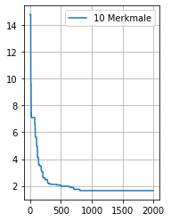

```python
Merkmal_10=genAlg(2000, 50, 10, 0.05, "10 Merkmale")
print("Distanz bei 10 Merkmalen: ", Merkmal_10)
```

```
bestIndividuum  ['power4' 'power10' 'power7' 'amp10std' 'amp1000dstd' 'amp100kurt'
 'power8' 'amp10dstd' 'amp1mean' 'amp10dskew' 'amp10skew']
Best mid rank: 1.6833333333333333
Population  [35 41 38  9 29 19 39 13  0 14 10]
Distanz bei 11 Merkmalen:  1.6833333333333333
```

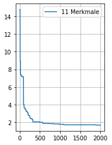

```python
Merkmal_11=genAlg(2000, 50, 11, 0.05 , "11 Merkmale")
print("Distanz bei 11 Merkmalen: ", Merkmal_11)
```

```
bestIndividuum  ['amp1mean' 'amp1000dstd' 'amp1skew' 'amp100dkurt' 'amp10kurt' 'power8'
 'power9' 'power4' 'power6' 'power2' 'power7' 'amp1mean']
Best mid rank: 1.9333333333333333
Population  [ 0 29  2 23 11 39 40 35 37 33 38  0]
Distanz bei 12 Merkmalen:  1.9333333333333333
```

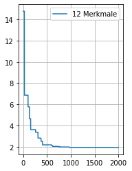

```python
Merkmal_12=genAlg(2000, 50, 12, 0.05 , "12 Merkmale")
print("Distanz bei 12 Merkmalen: ", Merkmal_12)
```

```
bestIndividuum  ['power6' 'amp10dskew' 'amp1mean' 'amp1skew' 'amp1std' 'power4'
 'amp100dkurt' 'amp1000std' 'power2' 'power7' 'amp10skew' 'power10'
 'amp100mean']
Best mid rank: 1.5666666666666667
Population  [37 14  0  2  1 35 23 25 33 38 10 41 16]
Distanz bei 13 Merkmalen:  1.5666666666666667
```

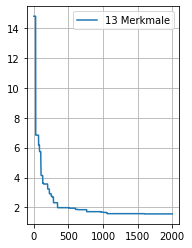

```python
Merkmal_13=genAlg(2000, 50, 13, 0.05 , "13 Merkmale")
print("Distanz bei 13 Merkmalen: ", Merkmal_13)
```

```
bestIndividuum  ['amp1000dstd' 'amp1mean' 'power1' 'amp100std' 'power7' 'amp1000mean'
 'power8' 'amp100kurt' 'power4' 'power2' 'amp10skew' 'amp1dskew' 'power10'
 'amp10std']
Best mid rank: 1.5166666666666666
Population  [29  0 32 17 38 24 39 19 35 33 10  6 41  9]
Distanz bei 14 Merkmalen:  1.5166666666666666
```

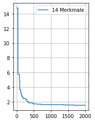

```python
Merkmal_14=genAlg(2000, 50, 14, 0.05 , "14 Merkmale")
print("Distanz bei 14 Merkmalen: ", Merkmal_14)
```

```
bestIndividuum  ['amp1mean' 'power2' 'amp1dskew' 'power7' 'amp100dkurt' 'power10' 'power4'
 'amp1000mean' 'amp10skew' 'amp100mean' 'amp10dskew' 'amp100dstd'
 'amp10std' 'power8' 'power9']
Best mid rank: 1.4833333333333334
Population  [ 0 33  6 38 23 41 35 24 10 16 14 21  9 39 40]
Distanz bei 15 Merkmalen:  1.4833333333333334
```

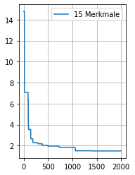

```python
Merkmal_15=genAlg(2000, 50, 15, 0.05 , "15 Merkmale")
print("Distanz bei 15 Merkmalen: ", Merkmal_15)
```

```
bestIndividuum  ['amp1mean' 'power7' 'amp10dskew' 'power2' 'power8' 'amp10dkurt'
 'amp1dskew' 'power10' 'amp1000dstd' 'power6' 'amp10skew' 'amp100kurt'
 'amp10std' 'power1' 'amp100dstd' 'amp1mean']
Best mid rank: 1.4666666666666666
Population  [ 0 38 14 33 39 15  6 41 29 37 10 19  9 32 21  0]
Distanz bei 16 Merkmalen:  1.4666666666666666
```

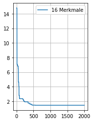

```python
Merkmal_16=genAlg(2000, 50, 16, 0.05 , "16 Merkmale")
print("Distanz bei 16 Merkmalen: ", Merkmal_16)
```

```
bestIndividuum  ['amp1mean' 'power9' 'amp10dstd' 'amp1dskew' 'amp100dstd' 'power2'
 'power4' 'amp100kurt' 'amp10mean' 'power10' 'power7' 'amp1000std'
 'amp1000dstd' 'amp1skew' 'power1' 'amp10dskew' 'amp10skew']
Best mid rank: 1.5
Population  [ 0 40 13  6 21 33 35 19  8 41 38 25 29  2 32 14 10]
Distanz bei 17 Merkmalen:  1.5
```

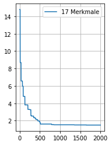

```python
Merkmal_17=genAlg(2000, 50, 17, 0.05 , "17 Merkmale")
print("Distanz bei 17 Merkmalen: ", Merkmal_17)
```

```
bestIndividuum  ['amp1mean' 'amp1mean' 'amp1mean' 'amp1mean' 'amp1skew' 'amp100dkurt'
 'power7' 'amp100std' 'amp10dskew' 'power6' 'power8' 'amp10skew'
 'amp100dstd' 'amp10dkurt' 'amp100mean' 'amp1000dstd' 'power1' 'power10']
Best mid rank: 1.4333333333333333
Population  [ 0  0  0  0  2 23 38 17 14 37 39 10 21 15 16 29 32 41]
Distanz bei 18 Merkmalen:  1.4333333333333333
```

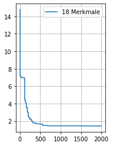

```python
Merkmal_18=genAlg(2000, 50, 18, 0.05 , "18 Merkmale")
print("Distanz bei 18 Merkmalen: ", Merkmal_18)
```

```
bestIndividuum  ['amp10dskew' 'power10' 'power2' 'amp1mean' 'power4' 'amp100dstd'
 'amp10kurt' 'amp1000dstd' 'amp1skew' 'power7' 'power9' 'power6'
 'amp10skew' 'amp1mean' 'amp1mean' 'amp1mean' 'amp1mean' 'amp1mean'
 'amp1mean']
Best mid rank: 1.5333333333333334
Population  [14 41 33  0 35 21 11 29  2 38 40 37 10  0  0  0  0  0  0]
Distanz bei 19 Merkmalen:  1.5333333333333334
```

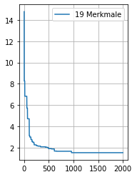

```python
Merkmal_19=genAlg(2000, 50, 19, 0.05 , "19 Merkmale")
print("Distanz bei 19 Merkmalen: ", Merkmal_19)
```

```
bestIndividuum  ['amp1mean' 'amp1mean' 'amp1mean' 'amp100kurt' 'power4' 'amp1000skew'
 'amp1dskew' 'power10' 'amp100mean' 'power8' 'amp10std' 'power6'
 'amp10skew' 'power1' 'amp1000std' 'amp100dstd' 'amp100std' 'amp10dskew'
 'amp100dmean' 'power7']
Best mid rank: 1.4333333333333333
Population  [ 0  0  0 19 35 26  6 41 16 39  9 37 10 32 25 21 17 14 20 38]
Distanz bei 20 Merkmalen:  1.4333333333333333
```

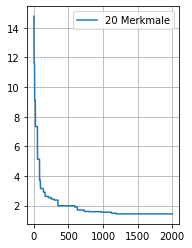

```python
Merkmal_20=genAlg(2000, 50, 20, 0.05 , "20 Merkmale")
print("Distanz bei 20 Merkmalen: ", Merkmal_20)
```

```
bestIndividuum  ['amp1mean' 'amp1dskew' 'amp10skew' 'amp1000std' 'power2' 'power1'
 'power9' 'amp1skew' 'amp100kurt' 'power10' 'amp10dstd' 'amp100dstd'
 'power8' 'power6' 'amp100std' 'power7' 'amp1mean' 'amp1mean' 'amp1mean'
 'amp1mean' 'amp1mean']
Best mid rank: 1.45
Population  [ 0  6 10 25 33 32 40  2 19 41 13 21 39 37 17 38  0  0  0  0  0]
Distanz bei 21 Merkmalen:  1.45
```

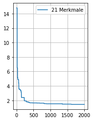

```python
Merkmal_21=genAlg(2000, 50, 21, 0.05 , "21 Merkmale")
print("Distanz bei 21 Merkmalen: ", Merkmal_21)
```

```python
#Alternative zu A3
#for merkmal in range(10, 30):
 #   m = genAlg(2000, 50, merkmal, 0.05, "{0}_features_genetic_algorithm: ".format(merkmal))
  #  print("Distanz bei {0} Merkmalen: ".format(merkmal), m)
```

Eine möglichtst kleine Merkmalsuntermenge mit möglichst gutem mittlerem Rang haben wir bei 18 und 20 Merkmalen gefunden. Der daraus resultierende mittlere Rang beträgt 1.43. wichtigste Merkmale sind:

'amp1mean' 'amp100kurt' 'power4' 'amp1000skew' 'amp1dskew' 'power10' 'amp100mean' 'power8' 'amp10std' 'power6' 'amp10skew' 'power1' 'amp1000std' 'amp10dskew' 'amp100dmean' 'power7'

1. Um wieviel verschlechtert sich der Mittlere Rang, wenn nur die 10 wichtigsten Merkmale benutzt werden?

1.65 - 1.45 = 0.20 Der Rang verschlechtert sich nur um 0.20. Der Unterschied zwischen 21 und 10 Merkmalen fällt nicht groß aus. Der Informationsgewinn bei zusätzlichen Features ist somit sehr gering.

#### Zusatz: Untersuchung der Mutation

Des weiteren wird der Algorithmus untersucht auf die Variation der Mutationswahrscheinlichkeit.

Diese findet in Abständen zwischen *[0.01, 0.05, 0.1, 0.2]* statt.

```
bestIndividuum  ['amp1mean' 'amp1000std' 'power9' 'power10' 'amp1000mean' 'amp1dskew'
 'power6' 'amp100dkurt' 'amp100mean' 'power1' 'amp10mean' 'amp10skew'
 'amp100std' 'amp1skew' 'power8' 'power7' 'power4' 'amp10std' 'amp10dskew']
Best mid rank: 1.4
Population  [ 0 25 40 41 24  6 37 23 16 32  8 10 17  2 39 38 35  9 14]
```

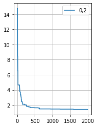

```python
mutation020 = genAlg(2000, 50, 19, 0.2, "0,2")
```

```
bestIndividuum  ['amp1mean' 'amp1mean' 'amp1mean' 'amp10std' 'amp10skew' 'power4'
 'amp100dkurt' 'amp1dskew' 'power8' 'power7' 'amp100std' 'power10'
 'amp1000std' 'power9' 'amp100dstd' 'amp10dskew' 'power6' 'power1'
 'amp1skew']
Best mid rank: 1.4
Population  [ 0  0  0  9 10 35 23  6 39 38 17 41 25 40 21 14 37 32  2]
```

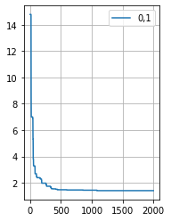

```python
mutation010 = genAlg(2000, 50, 19, 0.1, "0,1")
```

```
bestIndividuum  ['amp1mean' 'power7' 'amp10skew' 'amp100dstd' 'power10' 'amp10std'
 'power2' 'power6' 'amp1dskew' 'amp1000dstd' 'amp10dkurt' 'amp1skew'
 'amp10dskew' 'power4' 'amp100std' 'amp1000std' 'amp1000mean' 'amp1mean'
 'amp1mean']
Best mid rank: 1.4666666666666666
Population  [ 0 38 10 21 41  9 33 37  6 29 15  2 14 35 17 25 24  0  0]
```

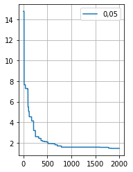

```python
mutation005 = genAlg(2000, 50, 19, 0.05, "0,05")
```

```
bestIndividuum  ['amp1mean' 'power4' 'amp1000dstd' 'amp1skew' 'amp10dkurt' 'power3'
 'amp1std' 'power9' 'power6' 'power2' 'amp1mean' 'amp1mean' 'amp1mean'
 'amp1mean' 'amp1mean' 'amp1mean' 'amp1mean' 'amp10skew' 'amp1mean']
Best mid rank: 2.066666666666667
Population  [ 0 35 29  2 15 34  1 40 37 33  0  0  0  0  0  0  0 10  0]
```

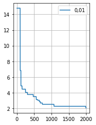

```python
mutation001 = genAlg(2000, 50, 19, 0.01, "0,01")
```

```python
#pop_mutation = [0.01, 0.05, 0.1, 0.2]

#for f in pop_mutation:
#    result = genAlg(2000, 50, 19, f, "{0}_features_genetic_algorithm: ".format(f))
#    print("Distanz bei {0} Merkmalen: ".format(result), f)
```

#### Zusatz: Untersuchung der Populationsgröße

```
bestIndividuum  ['amp1mean' 'amp100dstd' 'power2' 'amp1000std' 'amp10std' 'power10'
 'amp1skew' 'amp10dskew' 'amp1dskew' 'power4' 'amp100std' 'power8'
 'amp10skew' 'amp100kurt' 'power9' 'power7' 'amp1mean' 'amp1mean'
 'amp1mean']
Best mid rank: 1.45
Population  [ 0 21 33 25  9 41  2 14  6 35 17 39 10 19 40 38  0  0  0]
```

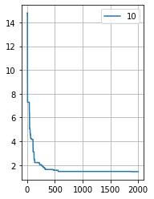

```python
popSize10 = genAlg(2000, 10, 19, 0.05, "10")
```

```
bestIndividuum  ['amp100std' 'amp1mean' 'amp1000kurt' 'amp10dskew' 'amp10dstd'
 'amp1000std' 'power8' 'power3' 'amp1std' 'amp10kurt' 'power2' 'amp1dskew'
 'power1' 'amp10skew' 'amp1000dmean' 'amp100mean' 'amp100dkurt' 'power10'
 'power4']
Best mid rank: 1.9
Population  [17  0 27 14 13 25 39 34  1 11 33  6 32 10 28 16 23 41 35]
```

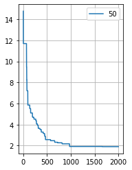

```python
popSize50 = genAlg(2000, 50, 19, 0.05, "50")
```

```python
popSize100 = genAlg(2000, 100, 19, 0.05, "100")
```

[output not shown]

## Clustering und automatische Playlistgenerierung

Implementieren Sie ein hierarchisches Clustering aller Subsequenzen in *subFeaturesTrain1.csv*. Diese *.csv*-Datei enthält nur die im vorigen Schritt ermittelten wichtigsten Merkmale. Das hierarchische Clustering ist in einem Dendrogram der Art wie in der unten gegebenen Abbildung zu visualisieren.

Die gefundenen Cluster sind mit den zugehörigen Musiktiteln in der Konsole auszugeben.

### Das Hierarchische Clustering

Das Hierarchische Clustering ist ein Typ des unüberwachten Lernens (engl., *Unsupervised Learning*). Dieser wird angewandt, um nicht gelabelte Datenpunkte zu clustern. Ähnlich dem K-means Clustering Algorithmus grupiert der Hierarchische Clustering Algorithmus Datenpunkte zusammen, welche ähnliche Charakteristiken aufweisen. In manchen Fällen kann das Ergebnis des hierarchischen, als auch K-means Clustering Algorithmus daher ähnliche sein. Die Hierarchie dieser Cluster wird als Baum Strukture (*Dendogram*) dargestellt. Die Wurzel dieses Baumes stellt das einzigartige Cluster dar, welches alle Stichproben an Datenpunkte (engl., *samples*) vereint. In den Blättern dagegen finden sich die einzelnen Cluster, die nur einen Datenpunktsatz enthalten.

**Aufgaben:**

1. Optimieren Sie die Parameter
   1. metric (Ähnlichkeitsmaß)
   2. linkage method
   3. Clusteranzahl

Die Ausgabe des Hierarchischen Clustering Algorithmus soll wie im Folgenden angelegt sein:

[figure not shown]

```python
import sklearn
import pandas as pd
import seaborn as sns
import numpy as np
from matplotlib import pyplot as plt
from sklearn.cluster import AgglomerativeClustering
from sklearn import preprocessing
```

```python
subFeatureTrain = pd.read_csv("subFeaturesTrain1.csv", index_col=0)
subFeatureTrain.head(5)
```

|  | amp1mean | amp10skew | amp1mean.1 | power6 | power2 | power7 | amp10dskew | amp1000std | power8 | power1 | ... | amp1dskew | amp1skew | amp10kurt | amp1mean.2 | amp1mean.3 | amp1mean.4 | amp1mean.5 | amp1mean.6 | amp1mean.7 | amp1mean.8 |
| --- | --- | --- | --- | --- | --- | --- | --- | --- | --- | --- | --- | --- | --- | --- | --- | --- | --- | --- | --- | --- | --- |
| Adele\01 Hometown Glory.mp3 | -2.117197 | 0.132666 | -2.117197 | 0.053639 | 0.227208 | 0.032771 | -0.000935 | 44.777066 | 0.028969 | 0.253978 | ... | 0.845604 | 0.473589 | 3.800743 | -2.117197 | -2.117197 | -2.117197 | -2.117197 | -2.117197 | -2.117197 | -2.117197 |
| Adele\02 I'll Be Waiting.mp3 | -4.417897 | -0.019593 | -4.417897 | 0.073520 | 0.179244 | 0.049261 | -0.034291 | 103.090380 | 0.047791 | 0.289610 | ... | 0.369870 | 0.137386 | 3.176607 | -4.417897 | -4.417897 | -4.417897 | -4.417897 | -4.417897 | -4.417897 | -4.417897 |
| Adele\03 Don't You Remember.mp3 | -5.919577 | -0.008191 | -5.919577 | 0.070985 | 0.191733 | 0.046546 | 0.053702 | 110.973039 | 0.066984 | 0.258719 | ... | 0.412036 | 0.210828 | 3.856293 | -5.919577 | -5.919577 | -5.919577 | -5.919577 | -5.919577 | -5.919577 | -5.919577 |
| Adele\04 Turning Tables.mp3 | -1.512483 | 0.056732 | -1.512483 | 0.074391 | 0.202309 | 0.045979 | -0.010719 | 39.803383 | 0.047494 | 0.224908 | ... | 0.530431 | 0.275351 | 3.096189 | -1.512483 | -1.512483 | -1.512483 | -1.512483 | -1.512483 | -1.512483 | -1.512483 |
| Adele\05 Set Fire To The Rain.mp3 | -3.252583 | -0.001415 | -3.252583 | 0.069513 | 0.199045 | 0.043936 | 0.029283 | 106.872136 | 0.049086 | 0.268530 | ... | 0.498193 | 0.191136 | 3.265215 | -3.252583 | -3.252583 | -3.252583 | -3.252583 | -3.252583 | -3.252583 | -3.252583 |

5 rows × 21 columns

#### Skalierung der Input Variablen

Um einen *Bias* des Models zu verhindern werden die Datensätze normalisiert, sodass alle die selbe Skalierung aufweisen.

```python
subFeatureTrainScaled = preprocessing.scale(subFeatureTrain)
subFeatureTrainScaled = pd.DataFrame(subFeatureTrainScaled, index=subFeatureTrain.index, columns=subFeatureTrain.columns)
subFeatureTrain = subFeatureTrainScaled
```

#### Datenanalyse mittels Heatmap

Mittels einer Heatmap können die Datensätze auf deren Verteilung und Ähnlichkeit zueinander untersucht werden. Als Farbgebung für diese Heatmap wurde "Viridis" genommen. Je stärker die Felder gelb eingefärbt sind, desto größer ist der Wert dieses Merkmals. Dies verhält sich ebenso umgekehrt mit dunkel-blau eingefärbten Werten. Hierdurch lässt sich visuell analysieren, welche Merkmale einen ähnlichen Wert haben und sich damit ähnlichsten sind.

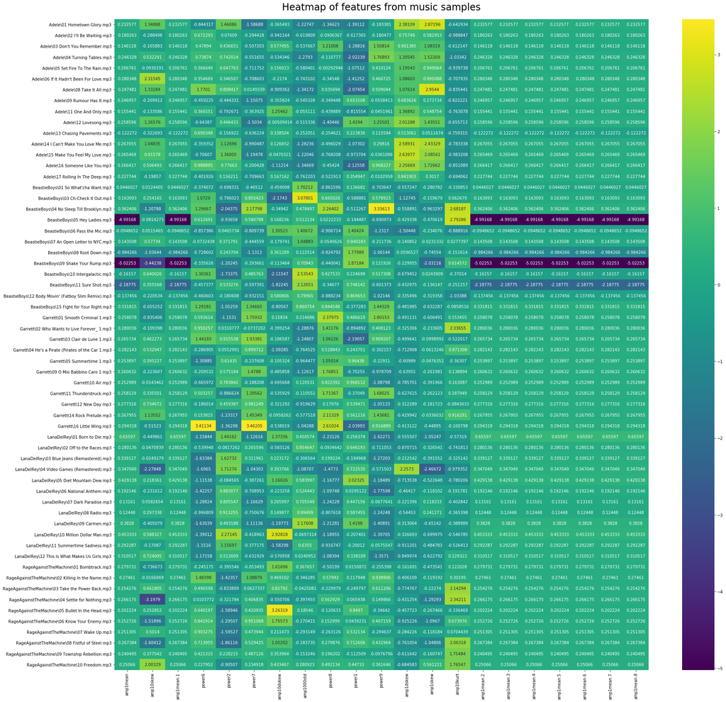

```python
fig, ax = plt.subplots(figsize=(30,30))
ax.axes.set_title("Heatmap of features from music samples", fontsize=24, y=1.01)
ax.set(xlabel='Features', ylabel='Importance');
sns.heatmap(subFeatureTrain, annot=True, fmt="g", cmap='viridis', ax=ax)
plt.savefig('heatmap_music_feature_dist.png')
plt.show()
```

```python
from scipy.cluster.hierarchy import dendrogram, linkage, fcluster
```

```
Cluster 1
BeastieBoys\05 Hey Ladies.mp3
BeastieBoys\09 Shake Your Rump.mp3
Cluster 2
BeastieBoys\08 Root Down.mp3
BeastieBoys\11 Sure Shot.mp3
Cluster 3
BeastieBoys\04 No Sleep Till Brooklyn.mp3
Garrett\03 Clair de Lune 1.mp3
Garrett\16 Little Wing.mp3
Cluster 4
Adele\02 I'll Be Waiting.mp3
Adele\03 Don't You Remember.mp3
Adele\05 Set Fire To The Rain.mp3
Adele\09 Rumour Has It.mp3
Adele\11 One And Only.mp3
Adele\13 Chasing Pavements.mp3
Adele\17 Rolling In The Deep.mp3
BeastieBoys\03 Ch-Check It Out.mp3
BeastieBoys\10 Intergalactic.mp3
BeastieBoys\15 Fight for Your Right.mp3
Garrett\01 Smooth Criminal 1.mp3
Garrett\02 Who Wants to Live Forever_ 1.mp3
Garrett\04 He's a Pirate (Pirates of the Car 1.mp3
Garrett\09 O Mio Babbino Caro 1.mp3
Garrett\11 Thunderstruck.mp3
Garrett\12 New Day.mp3
Garrett\14 Rock Prelude.mp3
RageAgainstTheMachine\01 Bombtrack.mp3
RageAgainstTheMachine\02 Killing In the Name.mp3
RageAgainstTheMachine\03 Take the Power Back.mp3
RageAgainstTheMachine\04 Settle for Nothing.mp3
RageAgainstTheMachine\05 Bullet In the Head.mp3
RageAgainstTheMachine\06 Know Your Enemy.mp3
RageAgainstTheMachine\07 Wake Up.mp3
RageAgainstTheMachine\08 Fistful of Steel.mp3
RageAgainstTheMachine\09 Township Rebellion.mp3
RageAgainstTheMachine\10 Freedom.mp3
Cluster 5
Adele\01 Hometown Glory.mp3
```

[output cut: 11 more lines]

```
BeastieBoys\12 Body Movin' (Fatboy Slim Remix).mp3
Garrett\05 Summertime 1.mp3
Garrett\10 Air.mp3
LanaDelRey\01 Born to Die.mp3
LanaDelRey\02 Off to the Races.mp3
LanaDelRey\03 Blue Jeans (Remastered).mp3
LanaDelRey\04 Video Games (Remastered).mp3
LanaDelRey\05 Diet Mountain Dew.mp3
LanaDelRey\06 National Anthem.mp3
LanaDelRey\07 Dark Paradise.mp3
LanaDelRey\08 Radio.mp3
LanaDelRey\09 Carmen.mp3
LanaDelRey\10 Million Dollar Man.mp3
LanaDelRey\11 Summertime Sadness.mp3
LanaDelRey\12 This Is What Makes Us Girls.mp3
```

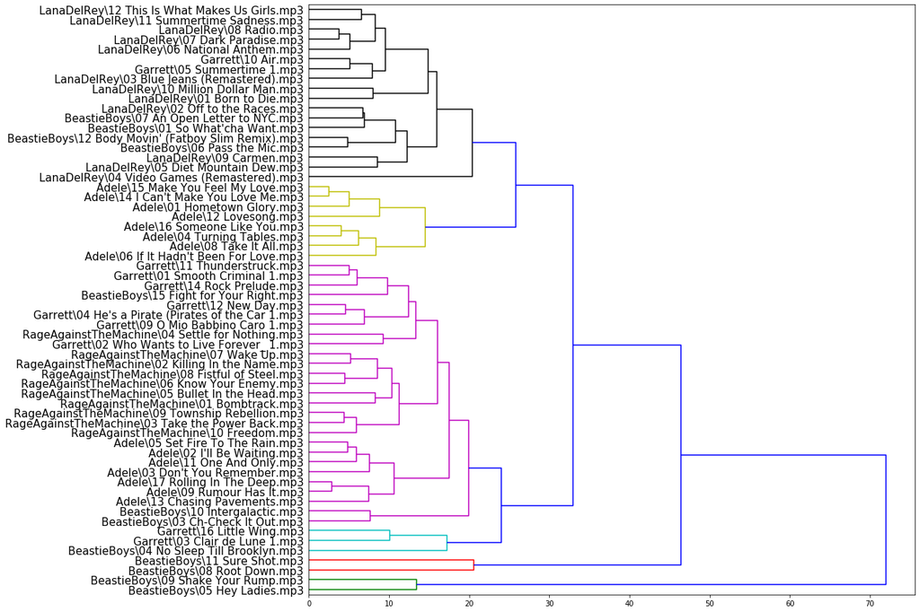

```python
linked = linkage(subFeatureTrain.to_numpy(), 'complete', 'cityblock')
cluster = fcluster(linked, 6, criterion='maxclust')
labelList = subFeatureTrain.index
plt.figure(figsize=(15,15))
dendrogram(linked,
          orientation='right',
          labels=labelList,
          distance_sort='descending',
          show_leaf_counts=True,
          leaf_font_size=15,
          color_threshold=23)

for c in range(1, cluster.max()+1):
    print("Cluster", c)
    for idx,i in enumerate(cluster):
        if i == c:
            print(subFeatureTrain.index[idx])

plt.show()
```

Subjektiv betrachtet ergeben die generierten Cluster (Playlists) Sinn. Künstler werden größtenteils in eine Playlist zusammengefasst, mit wenigen anderen Künstlern z.B. eine Playlist mit 12 LanaDelRey Songs und zwei anderen Künstlern. Zudem kann man Ausreißer-Cluster anhand von kleinen Playlists erkennen.

1. Für welche Parameterkonstellation erlangen Sie das für Sie subjektiv betrachtet günstigste Ergebnis?

   Parameterkonstellation:
   - metric (Ähnlichkeitsmaß): Cityblock
   - linkage method: complete
   - Clusteranzahl: 6
1. Überlegen Sie sich Ansätze um diese Art der Musikgruppierung zu verbessern?

Am nahe liegendsten wäre die Extraktion von weiteren Features wie z.B. Sprache, BPM, Spieldauer der Songs. Außerdem könnte man die Clustergröße anhand von einer Mindest- oder Maximalanzahl von Songs vordefinieren, um z.B. eine Playlist mit einer gewissen Spieldauer zu erstellen. Grundsätzlich ist es möglich ein anderes Verfahren zur Clusterbildung zu verwenden (z.B. K-Means).

Fazit:

Ein Durchlauf des genetischen Algorithmus dauert sehr lange. Dies hat das Testen und Entwickeln sehr zeitaufwendig gemacht. Mit mehr Zeit hätten wir sicher eine perfomantere Version entwickeln können und evtl threads einbauen können.Oder auch python libraries ausprobieren können wie pygalib, pyeasyga,...

## Zusatzaufgabe: Der Agglomerative Clustering Algorithmus

### Visuelle Analyse der Clusteranzahl mittels Dendrogram

Man kann ein Dendrogram auch zur Untersuchung der Datensätze, als auch zur Vorauswahl von Clustern heranziehen. Die Datensätze können dafür mittels einem Dendrogram näher untersucht werden und wichtige Rückschlüsse für die weitere verarbeitung gezogen werden. Dies gibt Aufschluss darüber, wie viele Cluster aus dem gesamten Datensatz (enlg., *sample* ) im Optimum hervorgebracht werden können. Die *x-Achse* enthält die Datensätze und die *y-Achse* stellt den Abstand (bzw. Unähnlichkeit) zwischen den Datensätzen dar. Je größer der Abstand, desto unähnlicher sind sich die Datensätze und umgekehrt.

```python
import scipy.cluster.hierarchy as shc
```

```python
def plot_hierarchical_cluster(data, method):
    plt.figure(figsize=(10, 7))
    plt.title("Cluster analysis Dendrogram, method={}".format(method))
    plt.xlabel('Music Titles Cluster')
    plt.ylabel('Euclidean distances')
    dend = shc.dendrogram(shc.linkage(data, method))
    # plot the line to make the threshhold visible
    plt.axhline(y=5, color='r', linestyle='--')
    plt.axhline(y=3, color='r', linestyle='--')
    plt.savefig('dendrogram_data_preprocessing_{}.png'.format(method))
    plt.show()
```

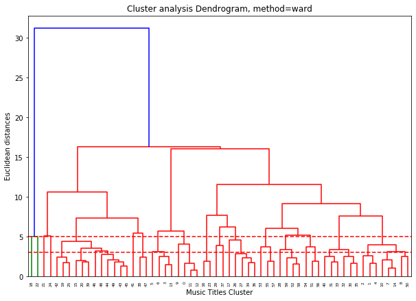

```python
plot_hierarchical_cluster(subFeatureTrain, 'ward')
```

#### Erkenntnis Dendrogram

Visuelle Untersuchung des Cluster Baumes in einem *Dendogram* veranschaulicht dessen Struktur. Im untersten Knoten, dem Blatt (*engl., leave*) werden die ähnlichsten Merkmale in einem Cluster zusammen gefasst. Diese Cluster erhalten die Label zwischen *1-n* der festgelegten Cluster Anazhl *n*.

#### Ausreißer erkennen ( *outlier detection* )

```python
def agglomerativeCluster(data, n_clusters, affinity, linkage):
    agglo_cluster_model = AgglomerativeClustering(n_clusters, affinity, linkage)
    return agglo_cluster_model.fit_predict(data)
```

### Trainieren des Agglomerative Clustering Algorithmus

#### Vorgehen

Zunächst wird jeder Punkt als ein separates Cluster betrachtet, dann werden die Punkte rekursiv in Abhängigkeit von der Entfernung zwischen ihnen gebündelt. Die Datenpunkte werden so gruppiert, dass der Abstand zwischen den Datenpunkten innerhalb eines Clusters minimal und der Abstand zwischen den Punkten innerhalb verschiedener Clusters maximal ist. Häufig verwendete Entfernungsmaße sind die euklidische Distanz, die Manhattan-Distanz oder die Mahalanobis-Distanz.

```python
cluster_lables = agglomerativeCluster(subFeatureTrain, n_clusters=3, affinity='euclidean', linkage='ward')
cluster_lables
```

```
array([0, 0, 0, 0, 0, 0, 0, 0, 0, 0, 0, 0, 0, 0, 0, 2, 0, 0, 1, 2, 2, 2,
       1, 0, 2, 2, 0, 0, 0, 0, 0, 0, 0, 0, 0, 0, 0, 0, 2, 2, 0, 2, 2, 2,
       2, 2, 2, 2, 2, 2, 0, 0, 0, 0, 0, 0, 0, 0, 0, 0], dtype=int64)
```

```python
subFeatureTrain.insert((subFeatureTrain.shape[1]), 'agglomerative', cluster_lables)
subFeatureTrain.head(5)
```

|  | amp1mean | amp10skew | amp1mean.1 | power6 | power2 | power7 | amp10dskew | amp1000std | power8 | power1 | ... | amp1skew | amp10kurt | amp1mean.2 | amp1mean.3 | amp1mean.4 | amp1mean.5 | amp1mean.6 | amp1mean.7 | amp1mean.8 | agglomerative |
| --- | --- | --- | --- | --- | --- | --- | --- | --- | --- | --- | --- | --- | --- | --- | --- | --- | --- | --- | --- | --- | --- |
| Adele\01 Hometown Glory.mp3 | 0.232577 | 1.348877 | 0.232577 | -0.844317 | 1.460863 | -1.586884 | -0.365493 | -1.227470 | -1.366235 | -1.391123 | ... | 2.872964 | -0.642934 | 0.232577 | 0.232577 | 0.232577 | 0.232577 | 0.232577 | 0.232577 | 0.232577 | 0 |
| Adele\02 I'll Be Waiting.mp3 | 0.180263 | -0.288498 | 0.180263 | 0.672293 | 0.076090 | -0.294418 | -0.941164 | -0.619809 | -0.090637 | -0.617365 | ... | 0.582953 | -0.988847 | 0.180263 | 0.180263 | 0.180263 | 0.180263 | 0.180263 | 0.180263 | 0.180263 | 0 |
| Adele\03 Don't You Remember.mp3 | 0.146118 | -0.165883 | 0.146118 | 0.478940 | 0.436651 | -0.507203 | 0.577455 | -0.537667 | 1.210078 | -1.288164 | ... | 1.083192 | -0.612147 | 0.146118 | 0.146118 | 0.146118 | 0.146118 | 0.146118 | 0.146118 | 0.146118 | 0 |
| Adele\04 Turning Tables.mp3 | 0.246328 | 0.532291 | 0.246328 | 0.738740 | 0.742014 | -0.551655 | -0.534346 | -1.279299 | -0.110777 | -2.022388 | ... | 1.522685 | -1.033416 | 0.246328 | 0.246328 | 0.246328 | 0.246328 | 0.246328 | 0.246328 | 0.246328 | 0 |
| Adele\05 Set Fire To The Rain.mp3 | 0.206761 | -0.093019 | 0.206761 | 0.366649 | 0.647763 | -0.711752 | 0.156023 | -0.580401 | -0.002929 | -1.075119 | ... | 0.949064 | -0.939738 | 0.206761 | 0.206761 | 0.206761 | 0.206761 | 0.206761 | 0.206761 | 0.206761 | 0 |

5 rows × 22 columns

```python
def get_cluster(df_data, n_cluster):
    music_cluster = []
    for n in range(1, n_cluster):
        playlist_recom = df_data.loc[df_data['agglomerative'] == n]
        music_cluster.append(playlist_recom)
        print('Cluster{0}: {1}'.format(n, playlist_recom))
    return music_cluster
```

```python
music_cluster = get_cluster(df_music_features, 3)
music_cluster
```

```
Cluster1: Empty DataFrame
Columns: [amp1mean, amp10skew, amp1mean.1, power6, power2, power7, amp10dskew, amp1000std, power8, power1, power9, amp1dskew, amp1skew, amp10kurt, amp1mean.2, amp1mean.3, amp1mean.4, amp1mean.5, amp1mean.6, amp1mean.7, amp1mean.8, agglomerative]
Index: []

[0 rows x 22 columns]
Cluster2: Empty DataFrame
Columns: [amp1mean, amp10skew, amp1mean.1, power6, power2, power7, amp10dskew, amp1000std, power8, power1, power9, amp1dskew, amp1skew, amp10kurt, amp1mean.2, amp1mean.3, amp1mean.4, amp1mean.5, amp1mean.6, amp1mean.7, amp1mean.8, agglomerative]
Index: []

[0 rows x 22 columns]
```

```
[Empty DataFrame
 Columns: [amp1mean, amp10skew, amp1mean.1, power6, power2, power7, amp10dskew, amp1000std, power8, power1, power9, amp1dskew, amp1skew, amp10kurt, amp1mean.2, amp1mean.3, amp1mean.4, amp1mean.5, amp1mean.6, amp1mean.7, amp1mean.8, agglomerative]
 Index: []

 [0 rows x 22 columns],
 Empty DataFrame
 Columns: [amp1mean, amp10skew, amp1mean.1, power6, power2, power7, amp10dskew, amp1000std, power8, power1, power9, amp1dskew, amp1skew, amp10kurt, amp1mean.2, amp1mean.3, amp1mean.4, amp1mean.5, amp1mean.6, amp1mean.7, amp1mean.8, agglomerative]
 Index: []

 [0 rows x 22 columns]]
```